# Credit Card fraud detection

The data was taken from Data-Flair’s [website](https://data-flair.training/blogs/data-science-machine-learning-project-credit-card-fraud-detection/)

```r
library(dplyr) # for data manipulation
library(stringr) # for data manipulation
library(caret) # for sampling
library(caTools) # for train/test split
library(ggplot2) # for data visualization
library(corrplot) # for correlations
library(rpart)# for decision tree model
library(randomForest)# for random forest model
library(xgboost) # for XGBoost model
library(PRROC) #for plotting ROC curve

set.seed(123)
```

# Loading in the Dataset

```r
df <- read.csv("creditcard.csv")
dim(df)
```

```
[1] 284807     31
```

# Exploratory Data Analysis

We now go through some preliminary steps to get a better understanding of our dataset

```r
head(df,6)
```

|  | Time | V1 | V2 | V3 | V4 | V5 | V6 | V7 | V8 | V9 | V10 | V11 | V12 | V13 | V14 | V15 | V16 | V17 | V18 | V19 | V20 | V21 | V22 | V23 | V24 | V25 | V26 | V27 | V28 | … |
| --- | --- | --- | --- | --- | --- | --- | --- | --- | --- | --- | --- | --- | --- | --- | --- | --- | --- | --- | --- | --- | --- | --- | --- | --- | --- | --- | --- | --- | --- | --- |
| 1 | 0 | -1.3598071 | -0.07278117 | 2.5363467 | 1.3781552 | -0.33832077 | 0.46238778 | 0.23959855 | 0.09869790 | 0.3637870 | 0.09079417 | -0.5515995 | -0.61780086 | -0.9913898 | -0.3111694 | 1.4681770 | -0.4704005 | 0.20797124 | 0.02579058 | 0.40399296 | 0.25141210 | -0.018306778 | 0.277837576 | -0.11047391 | 0.06692807 | 0.1285394 | -0.1891148 | 0.133558377 | -0.02105305 | … |
| 2 | 0 | 1.1918571 | 0.26615071 | 0.1664801 | 0.4481541 | 0.06001765 | -0.08236081 | -0.07880298 | 0.08510165 | -0.2554251 | -0.16697441 | 1.6127267 | 1.06523531 | 0.4890950 | -0.1437723 | 0.6355581 | 0.4639170 | -0.11480466 | -0.18336127 | -0.14578304 | -0.06908314 | -0.225775248 | -0.638671953 | 0.10128802 | -0.33984648 | 0.1671704 | 0.1258945 | -0.008983099 | 0.01472417 | … |
| 3 | 1 | -1.3583541 | -1.34016307 | 1.7732093 | 0.3797796 | -0.50319813 | 1.80049938 | 0.79146096 | 0.24767579 | -1.5146543 | 0.20764287 | 0.6245015 | 0.06608369 | 0.7172927 | -0.1659459 | 2.3458649 | -2.8900832 | 1.10996938 | -0.12135931 | -2.26185710 | 0.52497973 | 0.247998153 | 0.771679402 | 0.90941226 | -0.68928096 | -0.3276418 | -0.1390966 | -0.055352794 | -0.05975184 | … |
| 4 | 1 | -0.9662717 | -0.18522601 | 1.7929933 | -0.8632913 | -0.01030888 | 1.24720317 | 0.23760894 | 0.37743587 | -1.3870241 | -0.05495192 | -0.2264873 | 0.17822823 | 0.5077569 | -0.2879237 | -0.6314181 | -1.0596472 | -0.68409279 | 1.96577500 | -1.23262197 | -0.20803778 | -0.108300452 | 0.005273597 | -0.19032052 | -1.17557533 | 0.6473760 | -0.2219288 | 0.062722849 | 0.06145763 | … |
| 5 | 2 | -1.1582331 | 0.87773675 | 1.5487178 | 0.4030339 | -0.40719338 | 0.09592146 | 0.59294075 | -0.27053268 | 0.8177393 | 0.75307443 | -0.8228429 | 0.53819555 | 1.3458516 | -1.1196698 | 0.1751211 | -0.4514492 | -0.23703324 | -0.03819479 | 0.80348692 | 0.40854236 | -0.009430697 | 0.798278495 | -0.13745808 | 0.14126698 | -0.2060096 | 0.5022922 | 0.219422230 | 0.21515315 | … |
| 6 | 2 | -0.4259659 | 0.96052304 | 1.1411093 | -0.1682521 | 0.42098688 | -0.02972755 | 0.47620095 | 0.26031433 | -0.5686714 | -0.37140720 | 1.3412620 | 0.35989384 | -0.3580907 | -0.1371337 | 0.5176168 | 0.4017259 | -0.05813282 | 0.06865315 | -0.03319379 | 0.08496767 | -0.208253515 | -0.559824796 | -0.02639767 | -0.37142658 | -0.2327938 | 0.1059148 | 0.253844225 | 0.08108026 | … |

Since the original file was derived from real world financial data, it has been encoded into a form for privacy. By the looks of it, the columns might be results from a feature extrcat process like PCA. Our target column here is “Class”, where 0 indicates a safe transaction and 1 indicates a fraudulent one. Now, we look at the summary statistics.

```r
summary(df)
```

```
      Time              V1                  V2                  V3
 Min.   :     0   Min.   :-56.40751   Min.   :-72.71573   Min.   :-48.3256
 1st Qu.: 54202   1st Qu.: -0.92037   1st Qu.: -0.59855   1st Qu.: -0.8904
 Median : 84692   Median :  0.01811   Median :  0.06549   Median :  0.1799
 Mean   : 94814   Mean   :  0.00000   Mean   :  0.00000   Mean   :  0.0000
 3rd Qu.:139321   3rd Qu.:  1.31564   3rd Qu.:  0.80372   3rd Qu.:  1.0272
 Max.   :172792   Max.   :  2.45493   Max.   : 22.05773   Max.   :  9.3826
       V4                 V5                   V6                 V7
 Min.   :-5.68317   Min.   :-113.74331   Min.   :-26.1605   Min.   :-43.5572
 1st Qu.:-0.84864   1st Qu.:  -0.69160   1st Qu.: -0.7683   1st Qu.: -0.5541
 Median :-0.01985   Median :  -0.05434   Median : -0.2742   Median :  0.0401
 Mean   : 0.00000   Mean   :   0.00000   Mean   :  0.0000   Mean   :  0.0000
 3rd Qu.: 0.74334   3rd Qu.:   0.61193   3rd Qu.:  0.3986   3rd Qu.:  0.5704
 Max.   :16.87534   Max.   :  34.80167   Max.   : 73.3016   Max.   :120.5895
       V8                  V9                 V10                 V11
 Min.   :-73.21672   Min.   :-13.43407   Min.   :-24.58826   Min.   :-4.79747
 1st Qu.: -0.20863   1st Qu.: -0.64310   1st Qu.: -0.53543   1st Qu.:-0.76249
 Median :  0.02236   Median : -0.05143   Median : -0.09292   Median :-0.03276
 Mean   :  0.00000   Mean   :  0.00000   Mean   :  0.00000   Mean   : 0.00000
 3rd Qu.:  0.32735   3rd Qu.:  0.59714   3rd Qu.:  0.45392   3rd Qu.: 0.73959
 Max.   : 20.00721   Max.   : 15.59500   Max.   : 23.74514   Max.   :12.01891
      V12                V13                V14                V15
 Min.   :-18.6837   Min.   :-5.79188   Min.   :-19.2143   Min.   :-4.49894
 1st Qu.: -0.4056   1st Qu.:-0.64854   1st Qu.: -0.4256   1st Qu.:-0.58288
 Median :  0.1400   Median :-0.01357   Median :  0.0506   Median : 0.04807
 Mean   :  0.0000   Mean   : 0.00000   Mean   :  0.0000   Mean   : 0.00000
 3rd Qu.:  0.6182   3rd Qu.: 0.66251   3rd Qu.:  0.4931   3rd Qu.: 0.64882
 Max.   :  7.8484   Max.   : 7.12688   Max.   : 10.5268   Max.   : 8.87774
      V16                 V17                 V18                 V19
 Min.   :-14.12985   Min.   :-25.16280   Min.   :-9.498746   Min.   :-7.213527
 1st Qu.: -0.46804   1st Qu.: -0.48375   1st Qu.:-0.498850   1st Qu.:-0.456299
 Median :  0.06641   Median : -0.06568   Median :-0.003636   Median : 0.003735
 Mean   :  0.00000   Mean   :  0.00000   Mean   : 0.000000   Mean   : 0.000000
 3rd Qu.:  0.52330   3rd Qu.:  0.39968   3rd Qu.: 0.500807   3rd Qu.: 0.458949
 Max.   : 17.31511   Max.   :  9.25353   Max.   : 5.041069   Max.   : 5.591971
      V20                 V21                 V22                  V23
 Min.   :-54.49772   Min.   :-34.83038   Min.   :-10.933144   Min.   :-44.80774
 1st Qu.: -0.21172   1st Qu.: -0.22839   1st Qu.: -0.542350   1st Qu.: -0.16185
 Median : -0.06248   Median : -0.02945   Median :  0.006782   Median : -0.01119
 Mean   :  0.00000   Mean   :  0.00000   Mean   :  0.000000   Mean   :  0.00000
 3rd Qu.:  0.13304   3rd Qu.:  0.18638   3rd Qu.:  0.528554   3rd Qu.:  0.14764
 Max.   : 39.42090   Max.   : 27.20284   Max.   : 10.503090   Max.   : 22.52841
      V24                V25                 V26                V27
 Min.   :-2.83663   Min.   :-10.29540   Min.   :-2.60455   Min.   :-22.565679
 1st Qu.:-0.35459   1st Qu.: -0.31715   1st Qu.:-0.32698   1st Qu.: -0.070840
 Median : 0.04098   Median :  0.01659   Median :-0.05214   Median :  0.001342
 Mean   : 0.00000   Mean   :  0.00000   Mean   : 0.00000   Mean   :  0.000000
 3rd Qu.: 0.43953   3rd Qu.:  0.35072   3rd Qu.: 0.24095   3rd Qu.:  0.091045
 Max.   : 4.58455   Max.   :  7.51959   Max.   : 3.51735   Max.   : 31.612198
      V28                Amount             Class
 Min.   :-15.43008   Min.   :    0.00   Min.   :0.000000
 1st Qu.: -0.05296   1st Qu.:    5.60   1st Qu.:0.000000
 Median :  0.01124   Median :   22.00   Median :0.000000
 Mean   :  0.00000   Mean   :   88.35   Mean   :0.001728
 3rd Qu.:  0.07828   3rd Qu.:   77.17   3rd Qu.:0.000000
 Max.   : 33.84781   Max.   :25691.16   Max.   :1.000000
```

Another important aspect is checking if there are any missing values and how to handle them.

```r
colSums(is.na(df))
```

```
  Time     V1     V2     V3     V4     V5     V6     V7     V8     V9    V10    V11    V12
     0      0      0      0      0      0      0      0      0      0      0      0      0
   V13    V14    V15    V16    V17    V18    V19    V20    V21    V22    V23    V24    V25
     0      0      0      0      0      0      0      0      0      0      0      0      0
   V26    V27    V28 Amount  Class
     0      0      0      0      0
```

As seen above, there are no missing values. Now, we look at the value counts in our target variable.

```r
table(df$Class)
```

```
     0      1
284315    492
```

Clearly, we can see that our target is skewed extremely skewed, with 99% of the values as 0. This may create problems during model problems. There are various methods like downsampling, upsampling, ROSE, smote etc. that can be used to equalise the targets and get much better performance. We will not be using any of those, and training are models on the skewed data itself to view the raw results.

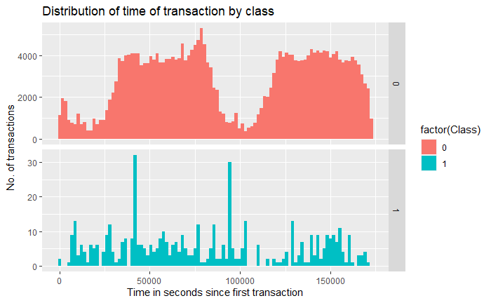

```r
df %>%
  ggplot(aes(x = Time, fill = factor(Class))) + geom_histogram(bins = 100)+
  labs(x = 'Time in seconds since first transaction', y = 'No. of transactions') +
  ggtitle('Distribution of time of transaction by class') +
  facet_grid(Class ~ ., scales = 'free_y')
```

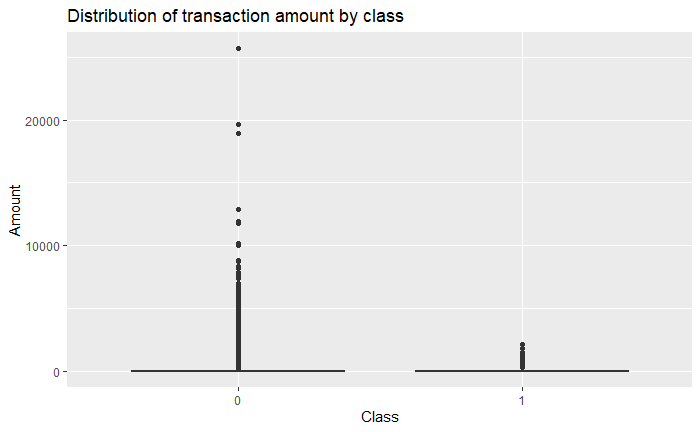

```r
ggplot(df, aes(x = factor(Class), y = Amount)) + geom_boxplot() +
labs(x = 'Class', y = 'Amount') +
ggtitle("Distribution of transaction amount by class")
```

An important observation from the above plot is that nearly all fraudulent transactions where of very small amounts.

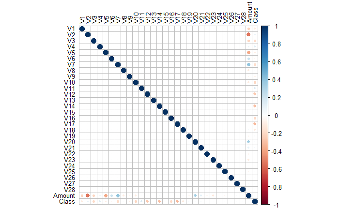

```r
correlations <- cor(df[,-1],method="pearson")
corrplot(correlations, number.cex = .9, method = "circle", type = "full", tl.cex=0.8,tl.col = "black")
```

Most of our features are uncorrelated, which means there is very little redundancy in the dataset. This further fuels our assumption that feature extraction was previously performed.

# Data Preprocessing

We first need to get rid of the “Time” column as it does not provide meaningful information to Tree-based models. We then convert our target column “Class” into categorical type as well as scale all the features.

```r
df <- df[,-1]
```

```r
df$Class <- as.factor(df$Class)
df[,-30] <- scale(df[,-30])

head(df)
```

|  | V1 | V2 | V3 | V4 | V5 | V6 | V7 | V8 | V9 | V10 | V11 | V12 | V13 | V14 | V15 | V16 | V17 | V18 | V19 | V20 | V21 | V22 | V23 | V24 | V25 | V26 | V27 | V28 | Amount | … |
| --- | --- | --- | --- | --- | --- | --- | --- | --- | --- | --- | --- | --- | --- | --- | --- | --- | --- | --- | --- | --- | --- | --- | --- | --- | --- | --- | --- | --- | --- | --- |
| 1 | -0.6942411 | -0.04407485 | 1.6727706 | 0.9733638 | -0.245116153 | 0.34706734 | 0.1936786 | 0.08263713 | 0.3311272 | 0.08338540 | -0.5404061 | -0.6182946 | -0.9960972 | -0.3246096 | 1.6040110 | -0.5368319 | 0.24486302 | 0.03076988 | 0.49628116 | 0.32611744 | -0.02492332 | 0.382853766 | -0.17691102 | 0.1105067 | 0.2465850 | -0.3921697 | 0.33089104 | -0.06378104 | 0.24496383 | … |
| 2 | 0.6084953 | 0.16117564 | 0.1097969 | 0.3165224 | 0.043483276 | -0.06181986 | -0.0637001 | 0.07125336 | -0.2324938 | -0.15334936 | 1.5800001 | 1.0660867 | 0.4914173 | -0.1499822 | 0.6943592 | 0.5294328 | -0.13516973 | -0.21876220 | -0.17908573 | -0.08961071 | -0.30737626 | -0.880075209 | 0.16220090 | -0.5611296 | 0.3206933 | 0.2610690 | -0.02225564 | 0.04460744 | -0.34247394 | … |
| 3 | -0.6934992 | -0.81157640 | 1.1694664 | 0.2682308 | -0.364571146 | 1.35145121 | 0.6397745 | 0.20737237 | -1.3786729 | 0.19069928 | 0.6118286 | 0.0661365 | 0.7206986 | -0.1731136 | 2.5629017 | -3.2982296 | 1.30686559 | -0.14478974 | -2.77855597 | 0.68097378 | 0.33763110 | 1.063356404 | 1.45631719 | -1.1380901 | -0.6285356 | -0.2884462 | -0.13713661 | -0.18102051 | 1.16068389 | … |
| 4 | -0.4933240 | -0.11216923 | 1.1825144 | -0.6097256 | -0.007468867 | 0.93614819 | 0.1920703 | 0.31601704 | -1.2625010 | -0.05046786 | -0.2218912 | 0.1783707 | 0.5101678 | -0.3003600 | -0.6898362 | -1.2092939 | -0.80544323 | 2.34530040 | -1.51420227 | -0.26985475 | -0.14744304 | 0.007266895 | -0.30477601 | -1.9410237 | 1.2419015 | -0.4602165 | 0.15539593 | 0.18618826 | 0.14053401 | … |
| 5 | -0.5913287 | 0.53154012 | 1.0214099 | 0.2846549 | -0.295014918 | 0.07199846 | 0.4793014 | -0.22650983 | 0.7443250 | 0.69162382 | -0.8061452 | 0.5386257 | 1.3522420 | -1.1680315 | 0.1913231 | -0.5152042 | -0.27908030 | -0.04556892 | 0.98703556 | 0.52993786 | -0.01283920 | 1.100009340 | -0.22012301 | 0.2332497 | -0.3952009 | 1.0416095 | 0.54361884 | 0.65181477 | -0.07340321 | … |
| 6 | -0.2174742 | 0.58167387 | 0.7525841 | -0.1188331 | 0.305008424 | -0.02231344 | 0.3849353 | 0.21795429 | -0.5176177 | -0.34110050 | 1.3140441 | 0.3601815 | -0.3597909 | -0.1430569 | 0.5655061 | 0.4584589 | -0.06844494 | 0.08190778 | -0.04077658 | 0.11021522 | -0.28352172 | -0.771425648 | -0.04227277 | -0.6132723 | -0.4465828 | 0.2196368 | 0.62889938 | 0.24563577 | -0.33855582 | … |

Now, we can perform a 7:3 split of the data to get our training and test set.

```r
set.seed(123)
split <- sample.split(df$Class, SplitRatio = 0.7)
train_df <-  subset(df, split == 1)
test_df <- subset(df, split == 0)

print(list(dim(train_df), dim(test_df)))
```

```
[[1]]
[1] 199364     30

[[2]]
[1] 85443    30
```

# Model Training

We aim to train 3 models and compare their Receiver Operating Characteristic plot, AUC, Accuracy and Test Positive Rate (TPR)

## Decision Tree

```r
dt_model <- rpart(Class ~ ., data = train_df)
summary(dt_model)
```

```
Call:
rpart(formula = Class ~ ., data = train_df)
  n= 199364

          CP nsplit rel error    xerror       xstd
1 0.47965116      0 1.0000000 1.0000000 0.05386985
2 0.05232558      1 0.5203488 0.5377907 0.03952081
3 0.03052326      3 0.4156977 0.4563953 0.03640997
4 0.02180233      5 0.3546512 0.4156977 0.03474992
5 0.01000000      8 0.2877907 0.3604651 0.03236065

Variable importance
V17 V12 V16 V10 V11 V18 V14 V27  V9  V6  V7 V26  V3 V22  V8  V4
 22  17  14  13  11  10   4   1   1   1   1   1   1   1   1   1

Node number 1: 199364 observations,    complexity param=0.4796512
  predicted class=0  expected loss=0.001725487  P(node) =1
    class counts: 199020   344
   probabilities: 0.998 0.002
  left son=2 (199057 obs) right son=3 (307 obs)
  Primary splits:
      V17 < -3.210609   to the right, improve=361.7704, (0 missing)
      V12 < -4.566125   to the right, improve=332.5387, (0 missing)
      V14 < -4.853395   to the right, improve=277.7936, (0 missing)
      V16 < -4.71675    to the right, improve=253.2370, (0 missing)
      V10 < -3.520583   to the right, improve=247.0641, (0 missing)
  Surrogate splits:
      V12 < -4.566125   to the right, agree=0.999, adj=0.658, (0 split)
      V16 < -4.71675    to the right, agree=0.999, adj=0.603, (0 split)
      V10 < -5.410415   to the right, agree=0.999, adj=0.459, (0 split)
      V11 < 4.062165    to the left,  agree=0.999, adj=0.417, (0 split)
      V18 < -4.441653   to the right, agree=0.999, adj=0.404, (0 split)

Node number 2: 199057 observations,    complexity param=0.05232558
  predicted class=0  expected loss=0.0005425582  P(node) =0.9984601
    class counts: 198949   108
   probabilities: 0.999 0.001
  left son=4 (199033 obs) right son=5 (24 obs)
  Primary splits:
      V14 < -8.580888   to the right, improve=36.708870, (0 missing)
```

[output cut: 145 more lines]

```

Node number 29: 59 observations
  predicted class=1  expected loss=0.1525424  P(node) =0.0002959411
    class counts:     9    50
   probabilities: 0.153 0.847

Node number 38: 8 observations
  predicted class=0  expected loss=0  P(node) =4.012761e-05
    class counts:     8     0
   probabilities: 1.000 0.000

Node number 39: 27 observations
  predicted class=1  expected loss=0.07407407  P(node) =0.0001354307
    class counts:     2    25
   probabilities: 0.074 0.926
```

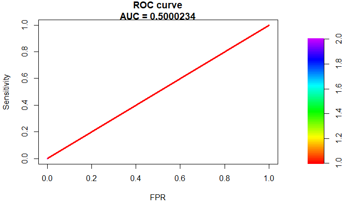

```r
dt_pred <- predict(dt_model, newdata = test_df, type = "class")
plot(roc.curve(test_df$Class, dt_pred, curve = TRUE))
```

```r
table(test_df$Class, dt_pred)
```

```
   dt_pred
        0     1
  0 85272    23
  1    27   121
```

```r
dt_acc = round((85272+121)/85443, 3)
dt_tpr = round(121/148, 3)
message("Accuracy of Decision Tree model = ", dt_acc)
```

```
Accuracy of Decision Tree model = 0.999
```

```r
message("True positive rate = ", dt_tpr)
```

```
True positive rate = 0.818
```

As seen above, we get a very low AUC, a very high accuracy and a decent TPR.

## Random Forest

```r
rf_model = randomForest( Class~., data = train_df, ntree = 200)
summary(rf_model)
```

```
                Length Class  Mode
call                 4 -none- call
type                 1 -none- character
predicted       199364 factor numeric
err.rate           600 -none- numeric
confusion            6 -none- numeric
votes           398728 matrix numeric
oob.times       199364 -none- numeric
classes              2 -none- character
importance          29 -none- numeric
importanceSD         0 -none- NULL
localImportance      0 -none- NULL
proximity            0 -none- NULL
ntree                1 -none- numeric
mtry                 1 -none- numeric
forest              14 -none- list
y               199364 factor numeric
test                 0 -none- NULL
inbag                0 -none- NULL
terms                3 terms  call
```

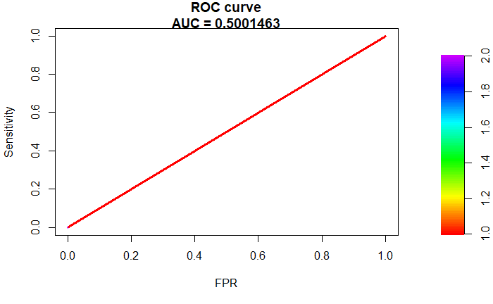

```r
rf_pred <- predict(rf_model, newdata = test_df[,-30], type = "class")
plot(roc.curve(test_df$Class, rf_pred, curve = TRUE))
```

```r
table(test_df$Class, rf_pred)
```

```
   rf_pred
        0     1
  0 85288     7
  1    32   116
```

```r
rf_acc = round((85288+116)/85443, 3)
rf_tpr = round(116/148, 3)
message("Accuracy of Random Forest model = ", rf_acc)
```

```
Accuracy of Random Forest model = 1
```

```r
message("True positive rate = ", rf_tpr)
```

```
True positive rate = 0.784
```

As seen above, we get a very low AUC, a very high accuracy and a TPR lower than that of the decision tree.

## Gradient Boosted Trees

```r
boost_model <- xgboost(data = data.matrix(train_df[,-30]),
 label = as.numeric(levels(train_df$Class))[train_df$Class],
 eta = 0.1,
 gamma = 0.1,
 max_depth = 10,
 nrounds = 300,
 objective = "multi:softmax",
 colsample_bytree = 0.6,
 verbose = 0,
 nthread = 7,
 num_class = 2,
 eval_metric = "merror"
)
summary(boost_model)
```

```
               Length  Class              Mode
handle               1 xgb.Booster.handle externalptr
raw            2324625 -none-             raw
niter                1 -none-             numeric
evaluation_log       2 data.table         list
call                21 -none-             call
params               9 -none-             list
callbacks            1 -none-             list
feature_names       29 -none-             character
nfeatures            1 -none-             numeric
```

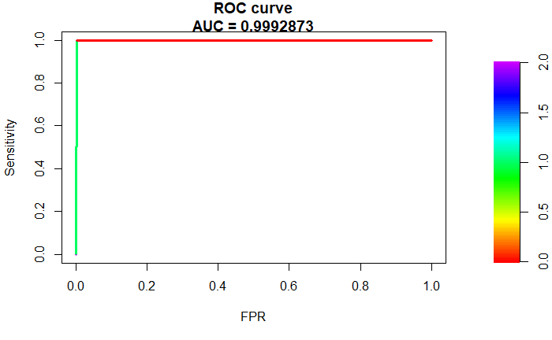

```r
boost_pred <- predict(boost_model, newdata = data.matrix(test_df[,-30]), type = "class")
plot(roc.curve(test_df$Class, boost_pred, curve = TRUE))
```

```r
table(test_df$Class, boost_pred)
```

```
   boost_pred
        0     1
  0 85292     3
  1    29   119
```

```r
boost_acc = round((85292+119)/85443, 3)
boost_tpr = round(119/148, 3)
message("Accuracy of Decision Tree model = ", boost_acc)
```

```
Accuracy of Decision Tree model = 1
```

```r
message("True positive rate = ", boost_tpr)
```

```
True positive rate = 0.804
```

As seen above, we get a excellent AUC, a very high accuracy and a TPR that is close to that of the decision tree.

# Observations

Out of all 3 tree-based models, the XGBoost model (gradient boosted trees) can be said to perform the best. Even though the decision tree had higher TPR, it had disappointing AUC. With regards to the Random Forest, better performance can be obtained by considerable hyperparameter tuning.